# Tvyal Newsletter

**Գծապատկեր 3.** Որքա՞ն է Հայաստանի ընտանիքների ամսական եկամուտը

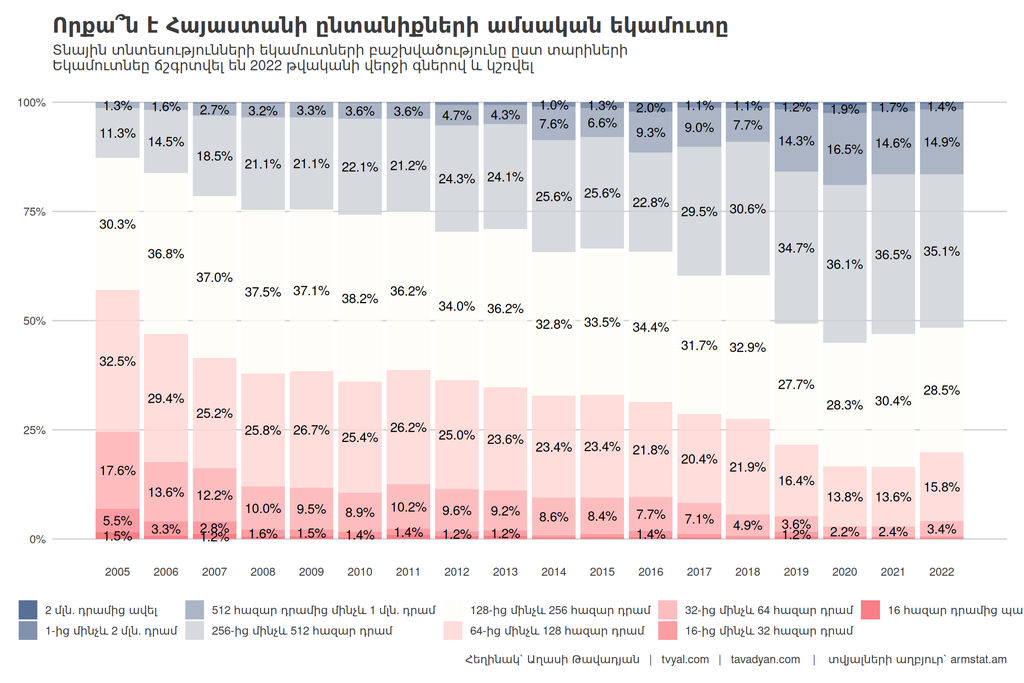

Ինչպես երևում է գծապատկերից մինչև 128 հազար դրամ ստացողները 3.5 տոկոսային կետով աճել են համեմատած 2021-ի։ 128-256 հազար դրամ ստացողների թիվը կրճատվել է 1.9 տոկոսային կետով։

Տվյալները առկա են 2005 թվականից։ Գծապատկերից նաև երևում է որ 2005 թվականից տնային տնտեսություններ գնաճով ճշգրտված եկամուտները գրանցել են կայուն աճ։ Ըստ տվյալների տնային տնտեսությունների իրական եկամուտները ամենամեծ աճն են արձանագրել 2006 և 2007, ինչպես նաև 2019 թվականին։

Անվանական եկամուտների աճ գրանցվել է նաև 2021 և 2022 թվականներին, սակայն այդ տարիներին գրանցվել է համապատասխանաբար 7.2 և 8.6 տոկոս գնաճ, որը զգալի իջեցրել է իրական եկամուտները։ Սա նշանակում է որ 2022 թվականի վերջին աշխատավարձերը դեռ չեն հասել գնաճի տեմպին և 2022 թվականին գրանցված 12.6 տոկոս տնտեսական աճը դեռ չի անդրադարձել տնային տնտեսությունների եկամուտների կամ աշխատավարձերի աճի վրա։ Նշեմ որ 2023 թվականի վերջին գրանցվել է գրեթե զրոյական գնաճ։ Զրոյական գնաճի տեսակետը ներկայացված է [տեսանյութում](https://youtu.be/Va5q9efWaI4)։

Երրորդ գծապատկերում ներկայացված միտքը այլընտրանքային կերպով արտացոլում է նաև հաջորդ գծապատկերը։

**Գծապատկեր 4.** Որքա՞ն է Հայաստանի ընտանիքների ամսական եկամուտը, այլընտրանքային հայացք

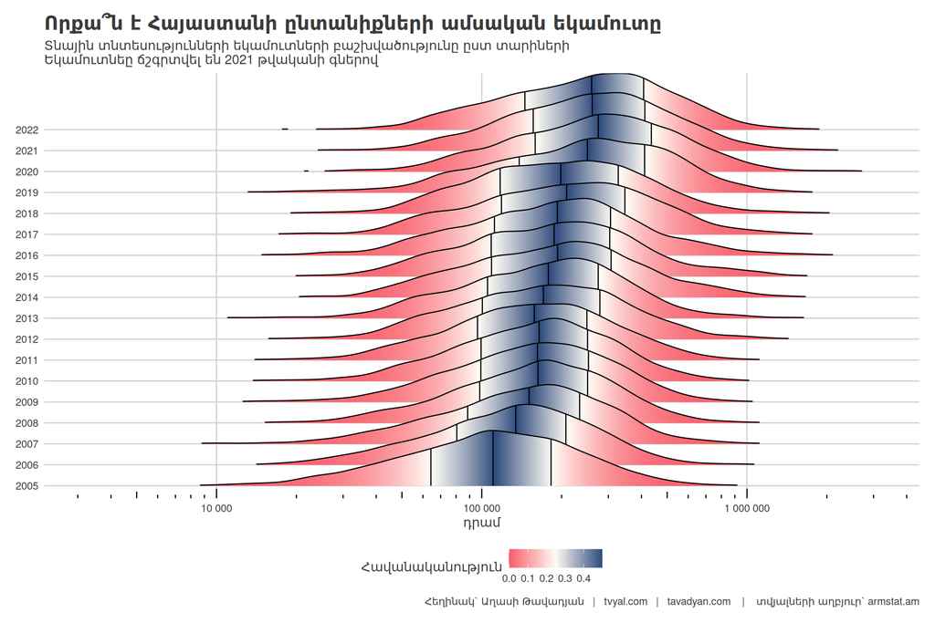

Այղուսակի տեսքով ներկայացնենք նաև տնային տնտեսությունների եկամուտների փոփոխությունը տարիների ընթացքում։

| Տարի | Ամենաաղքատ 10%-ի վերին շեմը (1-ին դեցիլ) | Միջին ընտանիքի եկամուտ (median) | Միջին եկամուտ (mean) | Ամենահարուստ 10%-ի ստորին շեմը (9-րդ դեցիլ) |
| --- | --- | --- | --- | --- |
| 2005 | 43 | 130 | 157 | 292 |
| 2006 | 46 | 149 | 181 | 327 |
| 2007 | 51 | 175 | 209 | 389 |
| 2008 | 62 | 180 | 227 | 425 |
| 2009 | 69 | 203 | 236 | 447 |
| 2010 | 70 | 202 | 240 | 471 |
| 2011 | 74 | 202 | 241 | 450 |
| 2012 | 74 | 223 | 263 | 485 |
| 2013 | 71 | 211 | 250 | 472 |
| 2014 | 70 | 226 | 284 | 555 |
| 2015 | 72 | 225 | 283 | 548 |
| 2016 | 76 | 226 | 330 | 696 |
| 2017 | 79 | 250 | 311 | 585 |
| 2018 | 95 | 274 | 322 | 567 |
| 2019 | 103 | 316 | 365 | 642 |
| 2020 | 107 | 286 | 354 | 631 |
| 2021 | 107 | 291 | 344 | 633 |
| 2022 | 96 | 288 | 354 | 674 |

Տվյալները վերցված են պաշտոնական աղբյուրներից, մասնավորապես՝ [տնային տնտեսությունների կենսամակարդակի (կենսապայմանների) ամբողջացված հետազոտության անվանազերծված միկրոտվյալների բազա (ըստ տնային տնտեսությունների)](https://www.armstat.am/en/?nid=205) և [Հայաստանի սպառողական գների ամսական ինդեքսը](https://www.cba.am/stat/stat_data_arm/6_CPI_arm.xls): Տնային տնտեսությունների կենսամակարդակի ցուցանիշները ճշգրտվել են ամսական կումուլատիվ գնաճով, այսինքն յուրաքանչյուր ցուցանիշ ներկայացնում է 2022 թվականի վերջի գնողունակությունը։ Ցուցանիշները նաև կշռվել են։ Հաշվարկները կարելի է ստուգել այցելելով [github-ի](https://github.com/tavad/tvyal_newsletter) մեր էջը, որտեղ տրված են տվյալները, հաշվարկների և գծապատկերների կոդը։